# Clinical Data Exploration

Carlos Ruiz

2024-04-16

# Introduction

In this document, I will explore the clinical variables present in the IPPSmol dataset.

# Data loading

```r
library(tidyverse)
library(GGally)
library(survival)
library(survminer)
library(cowplot)
```

```r
load("../results/preprocess/clinical_preproc.Rdata")
```

```r
colnames(clinical_all)
```

```
##  [1] "ID"                      "MDS_TYPE"
##  [3] "SEX"                     "AGE"
##  [5] "WHO_2016"                "BM_BLAST"
##  [7] "PB_BLAST"                "WBC"
##  [9] "ANC"                     "MONOCYTES"
## [11] "HB"                      "PLT"
## [13] "RINGED_SIDEROBLASTS"     "IPSSR"
## [15] "IPSSR_SCORE"             "IPSSRA"
## [17] "IPSSRA_SCORE"            "IPSSM"
## [19] "IPSSM_SCORE"             "CYTOGENETICS"
## [21] "CYTO_IPSSR"              "complex"
## [23] "chr17"                   "CNACS_chrarm_loss"
## [25] "CNACS_gene_loss"         "CNACS_chrarm_gain"
## [27] "CNACS_gene_gain"         "CNACS_chrarm_upd"
## [29] "CNACS_gene_upd"          "OS_YEARS"
```

[output cut: 32 more lines]

The dataset contains 2957 individuals and 94 variables.

# Data exploration

Define functions

```r
plot_continuous <- function(var, binwidth){
  ggplot(clinical_all, aes(x = .data[[var]])) +
    geom_histogram(binwidth = binwidth) +
    theme_bw()
}

descrip_continuous <- function(var, thres){
  clinical_all %>%
    mutate(intervals = cut_interval(.data[[var]], thres)) %>%
    count(intervals) %>%
    mutate(perc = round(n/sum(n)*100, 1))
}


plot_categorical <- function(var){
  ggplot(clinical_all, aes(x = .data[[var]])) +
    geom_bar() +
    theme_bw()
}

descrip_categorical <- function(var){
  clinical_all %>%
    count(.data[[var]]) %>%
    mutate(perc = round(n/sum(n)*100, 1))
}
```

## Demographic variables

The cohort contains two demographic variables: age and sex.

```r
demo_vars <- c("AGE", "SEX")
```

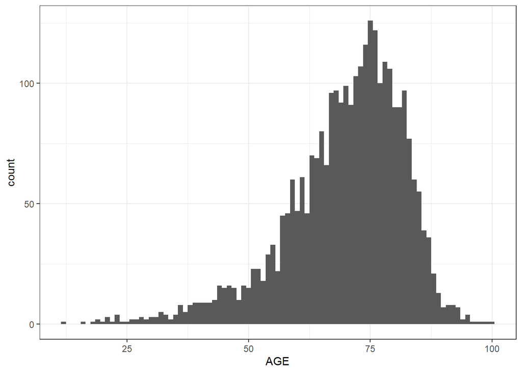

```r
plot_continuous("AGE", 1)
```

```r
descrip_continuous("AGE", 10)
```

```
## # A tibble: 11 × 3
##    intervals       n  perc
##    <fct>       <int> <dbl>
##  1 [12,20.8]       6   0.2
##  2 (20.8,29.6]    19   0.6
##  3 (29.6,38.4]    42   1.4
##  4 (38.4,47.2]   108   3.7
##  5 (47.2,56]     189   6.4
##  6 (56,64.8]     444  15
##  7 (64.8,73.6]   831  28.1
##  8 (73.6,82.4]   956  32.3
##  9 (82.4,91.2]   316  10.7
## 10 (91.2,100]     26   0.9
## 11 <NA>           20   0.7
```

Most individuals are between 56 and 90 years old. Nonetheless, 11.64% of the individuals are younger than 56, being 0.85% younger than 30. In addition, 0.68% have missing age.

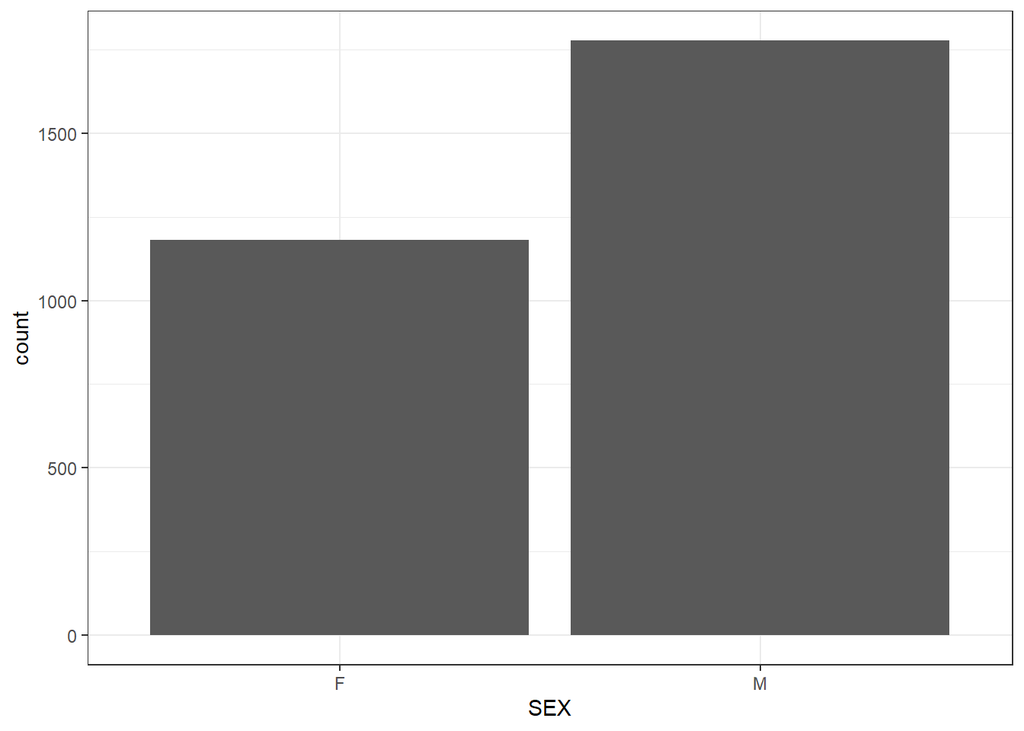

```r
plot_categorical("SEX")
```

```r
descrip_categorical("SEX")
```

```
## # A tibble: 2 × 3
##   SEX       n  perc
##   <chr> <int> <dbl>
## 1 F      1181  39.9
## 2 M      1776  60.1
```

There are more men than woman.

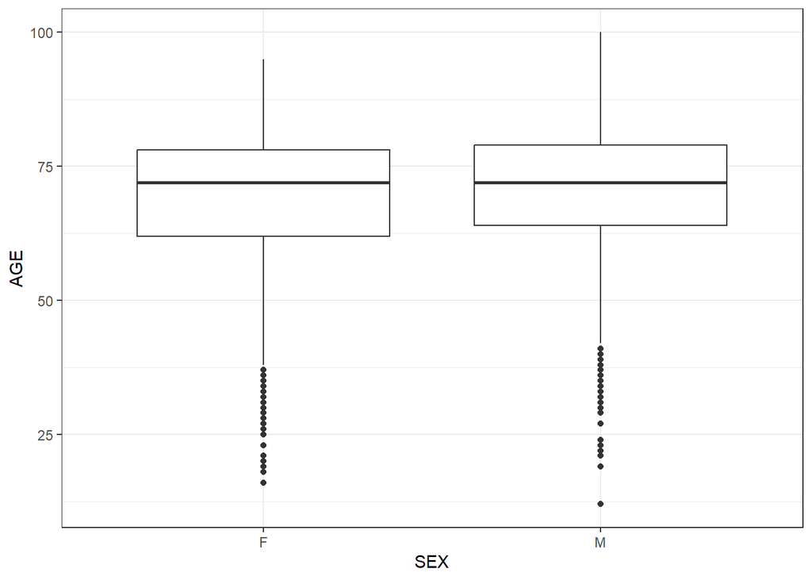

```r
ggplot(clinical_all, aes(x = SEX, y = AGE)) +
  geom_boxplot() +
  theme_bw()
```

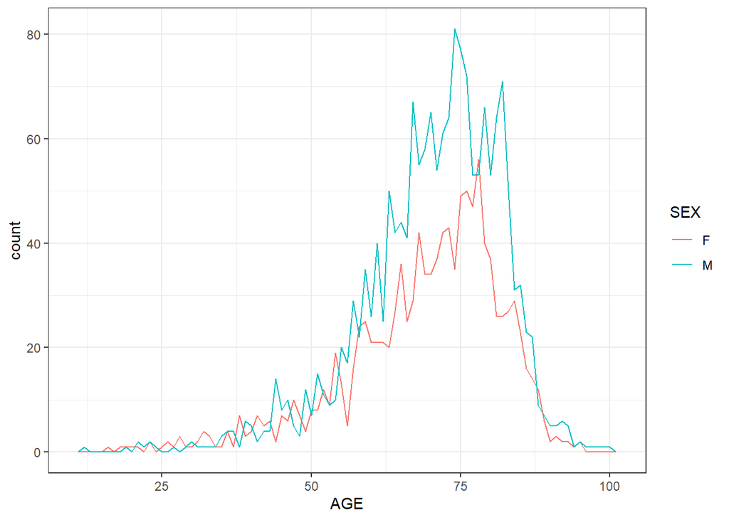

```r
ggplot(clinical_all, aes(x = AGE, color = SEX)) +
 geom_freqpoly( binwidth = 1) + theme_bw()
```

The age distribution seems very similar in men than women

## Clinical variables

```r
clin_vars <- c("BM_BLAST", "PB_BLAST", "WBC", "ANC", "MONOCYTES", "HB", "PLT")
```

### Bone marrow blasts (%)

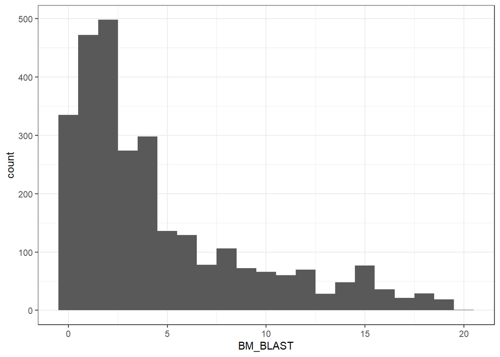

```r
plot_continuous("BM_BLAST", 1)
```

```r
descrip_continuous("BM_BLAST", 10)
```

```
## # A tibble: 11 × 3
##    intervals     n  perc
##    <fct>     <int> <dbl>
##  1 [0,2]      1305  44.1
##  2 (2,4]       572  19.3
##  3 (4,6]       265   9
##  4 (6,8]       184   6.2
##  5 (8,10]      138   4.7
##  6 (10,12]     130   4.4
##  7 (12,14]      76   2.6
##  8 (14,16]     113   3.8
##  9 (16,18]      50   1.7
## 10 (18,20]      20   0.7
## 11 <NA>        104   3.5
```

Bone marrow blasts show a tail distribution, with most individuals between 0 and 5% but a tail up to 20%.

### Peripheral blood blasts (%)

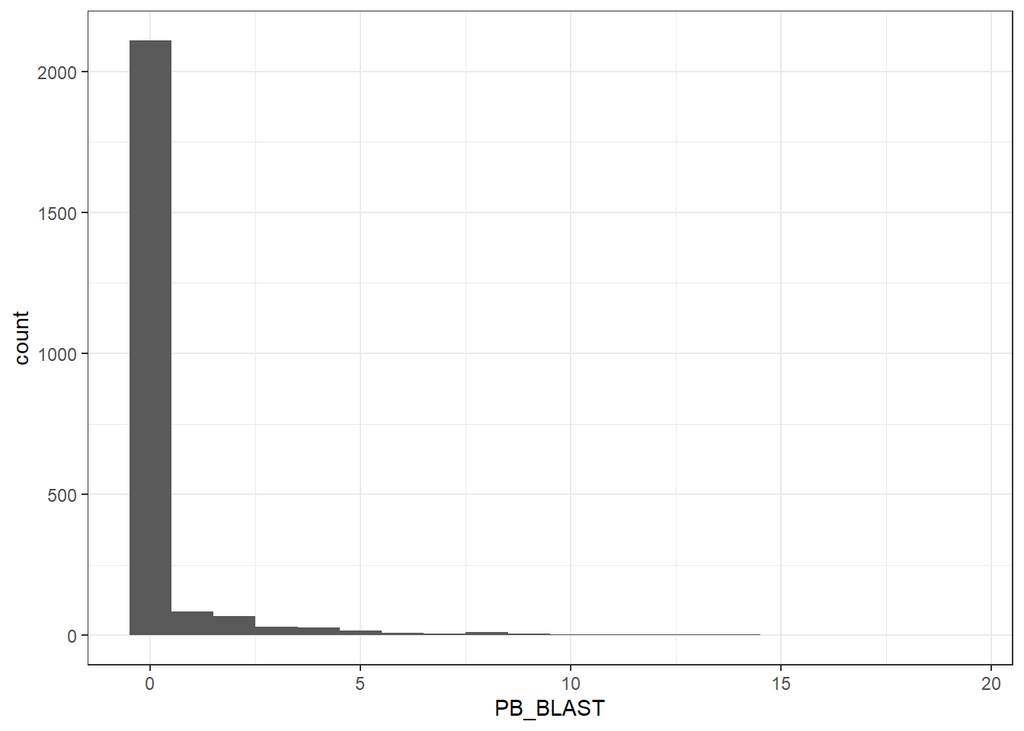

```r
plot_continuous("PB_BLAST", 1)
```

```r
descrip_continuous("PB_BLAST", 10)
```

```
## # A tibble: 11 × 3
##    intervals       n  perc
##    <fct>       <int> <dbl>
##  1 [0,1.9]      2195  74.2
##  2 (1.9,3.8]     100   3.4
##  3 (3.8,5.7]      46   1.6
##  4 (5.7,7.6]      15   0.5
##  5 (7.6,9.5]      17   0.6
##  6 (9.5,11.4]      8   0.3
##  7 (11.4,13.3]     8   0.3
##  8 (13.3,15.2]     4   0.1
##  9 (15.2,17.1]     3   0.1
## 10 (17.1,19]       1   0
## 11 <NA>          560  18.9
```

Most individuals did not have blasts in peripheral blood. A high proportion of samples (18.94%) had missing values.

### Whole blood cell counts (Giga/L)

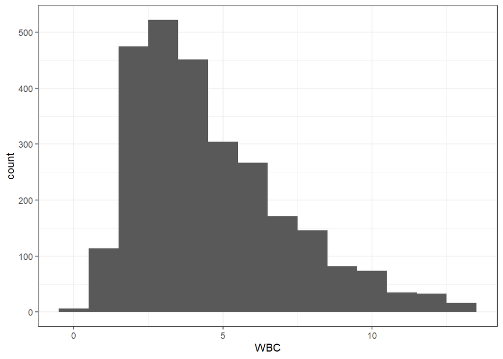

```r
plot_continuous("WBC", 1)
```

```r
descrip_continuous("WBC", 10)
```

```
## # A tibble: 11 × 3
##    intervals       n  perc
##    <fct>       <int> <dbl>
##  1 [0,1.3]       120   4.1
##  2 (1.3,2.6]     475  16.1
##  3 (2.6,3.9]     522  17.7
##  4 (3.9,5.2]     755  25.5
##  5 (5.2,6.5]     267   9
##  6 (6.5,7.8]     171   5.8
##  7 (7.8,9.1]     228   7.7
##  8 (9.1,10.4]     74   2.5
##  9 (10.4,11.7]    35   1.2
## 10 (11.7,13]      49   1.7
## 11 <NA>          261   8.8
```

Most samples had white blood cell counts between 1.6 and 6.6 Giga/L. A relevant proportion of samples (8.83%) had missing values for white blood cell counts.

### Absolute Neutrophil Count (Giga/L)

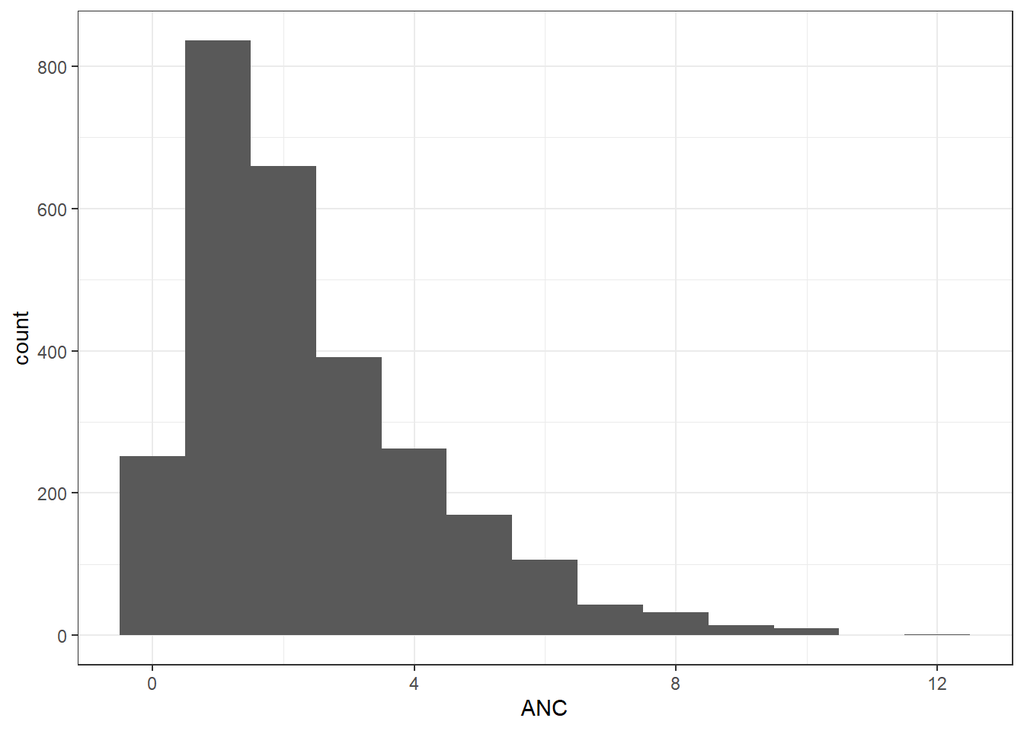

```r
plot_continuous("ANC", 1)
```

```r
descrip_continuous("ANC", 10)
```

```
## # A tibble: 11 × 3
##    intervals      n  perc
##    <fct>      <int> <dbl>
##  1 [0,1.2]     1088  36.8
##  2 (1.2,2.4]    660  22.3
##  3 (2.4,3.6]    391  13.2
##  4 (3.6,4.8]    263   8.9
##  5 (4.8,6]      275   9.3
##  6 (6,7.2]       43   1.5
##  7 (7.2,8.4]     33   1.1
##  8 (8.4,9.6]     14   0.5
##  9 (9.6,10.8]    10   0.3
## 10 (10.8,12]      1   0
## 11 <NA>         179   6.1
```

### Monocyte Count (Giga/L)

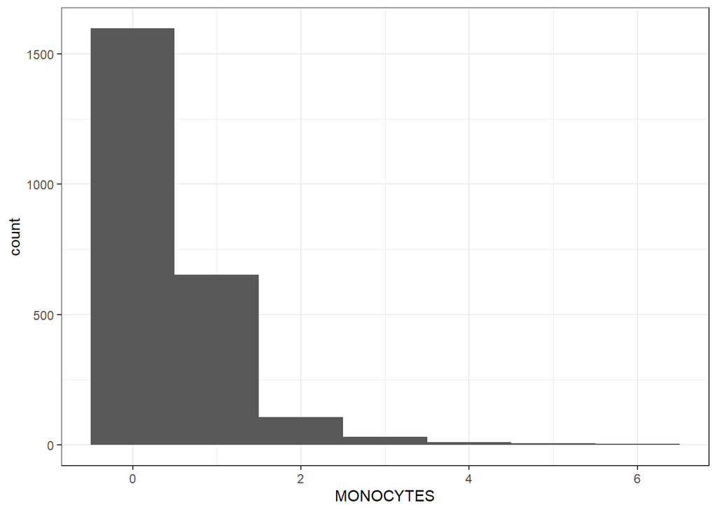

```r
plot_continuous("MONOCYTES", 1)
```

```r
descrip_continuous("MONOCYTES", 10)
```

```
## # A tibble: 8 × 3
##   intervals     n  perc
##   <fct>     <int> <dbl>
## 1 [0,0.6]    1597  54
## 2 (0.6,1.2]   653  22.1
## 3 (1.8,2.4]   108   3.7
## 4 (2.4,3]      32   1.1
## 5 (3.6,4.2]    10   0.3
## 6 (4.8,5.4]     6   0.2
## 7 (5.4,6]       4   0.1
## 8 <NA>        547  18.5
```

### Hemoglobin (g/dL)

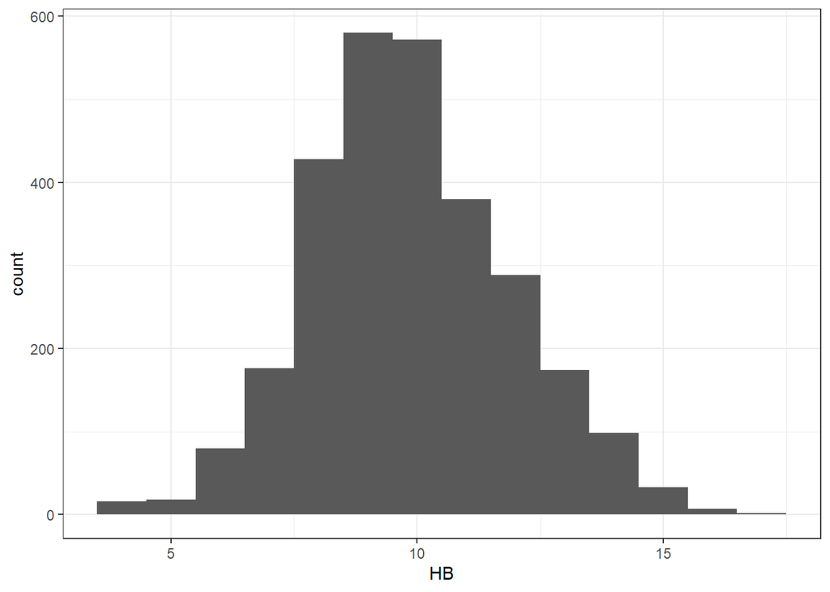

```r
plot_continuous("HB", 1)
```

```r
descrip_continuous("HB", 10)
```

```
## # A tibble: 11 × 3
##    intervals       n  perc
##    <fct>       <int> <dbl>
##  1 [4,5.3]        34   1.1
##  2 (5.3,6.6]      80   2.7
##  3 (6.6,7.9]     176   6
##  4 (7.9,9.2]    1008  34.1
##  5 (9.2,10.5]    572  19.3
##  6 (10.5,11.8]   380  12.9
##  7 (11.8,13.1]   462  15.6
##  8 (13.1,14.4]    98   3.3
##  9 (14.4,15.7]    33   1.1
## 10 (15.7,17]       9   0.3
## 11 <NA>          105   3.6
```

Most samples had hemoglobin proportions between 8 and 12 g/dL.

### Platelets (Giga/L)

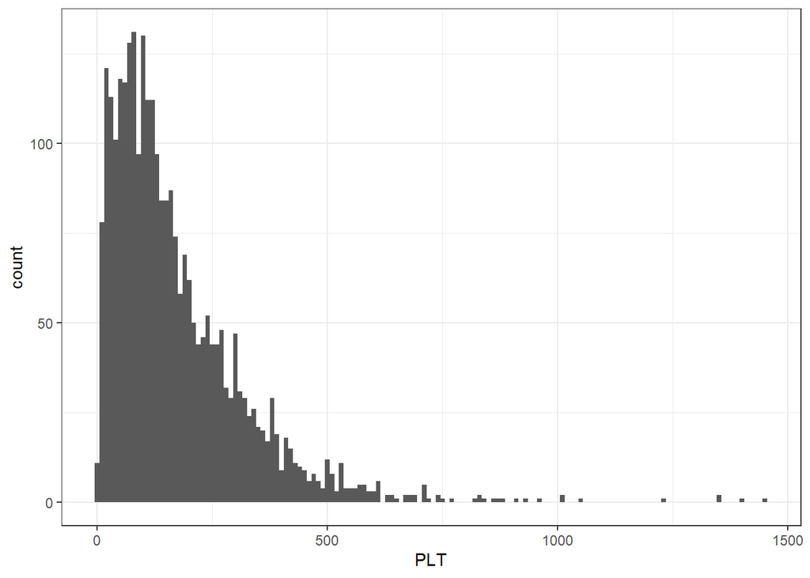

```r
plot_continuous("PLT", 10)
```

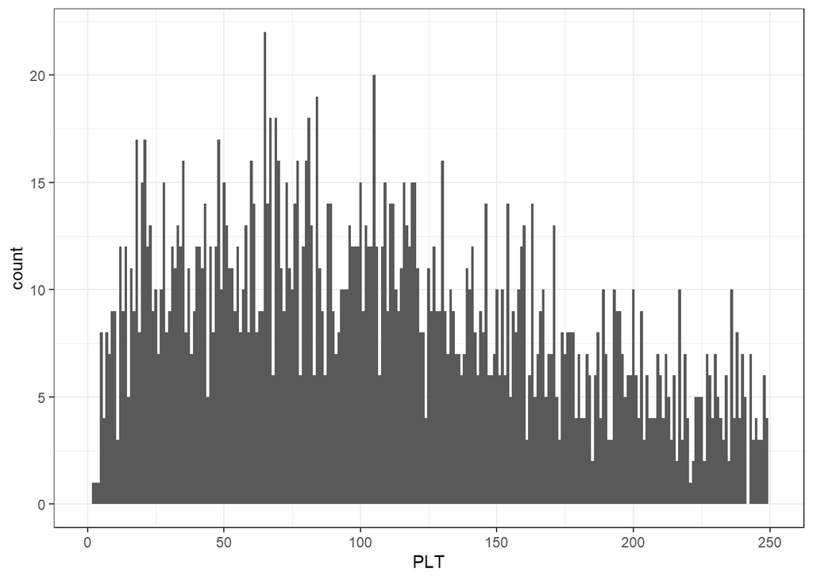

```r
plot_continuous("PLT", 1) +
  xlim(c(0, 250))
```

```r
descrip_continuous("PLT", 10)
```

```
## # A tibble: 11 × 3
##    intervals               n  perc
##    <fct>               <int> <dbl>
##  1 [2,147]              1564  52.9
##  2 (147,292]             795  26.9
##  3 (292,437]             330  11.2
##  4 (437,582]              99   3.3
##  5 (582,726]              29   1
##  6 (726,871]               9   0.3
##  7 (871,1.02e+03]          7   0.2
##  8 (1.02e+03,1.16e+03]     1   0
##  9 (1.16e+03,1.31e+03]     1   0
## 10 (1.31e+03,1.45e+03]     4   0.1
## 11 <NA>                  118   4
```

Most samples had platelet count values below 200 Giga/L. Original studied capped the platelet values to 250.

### Ringed Sideroblasts (Giga/L)

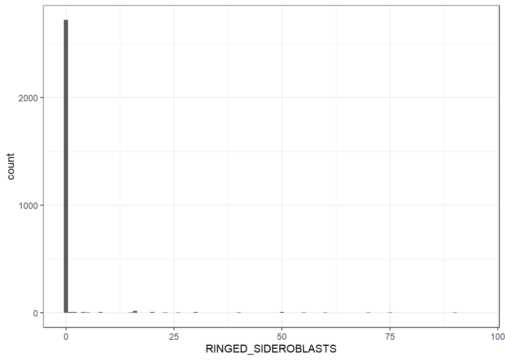

```r
plot_continuous("RINGED_SIDEROBLASTS", 1)
```

```r
descrip_continuous("RINGED_SIDEROBLASTS", 10)
```

```
## # A tibble: 10 × 3
##    intervals     n  perc
##    <fct>     <int> <dbl>
##  1 [0,9.5]    2770  93.7
##  2 (9.5,19]     33   1.1
##  3 (19,28.5]    28   0.9
##  4 (28.5,38]    29   1
##  5 (38,47.5]    18   0.6
##  6 (47.5,57]    25   0.8
##  7 (57,66.5]    16   0.5
##  8 (66.5,76]    18   0.6
##  9 (76,85.5]    10   0.3
## 10 (85.5,95]    10   0.3
```

We assumed that individuals without ringed sideroblasts data did not have this event.

## Cytogenetics

```r
kar_events <- c("monoy", "del11q", "del5q", "del12p",
                "del20q", "del7q", "triso8", "triso19", "mono7",
                "i17q", "chr3ab", "any_aberration")

cyto <- c("CYTO_IPSSR", "complex", kar_events)
```

### Cytogenetics IPSSR

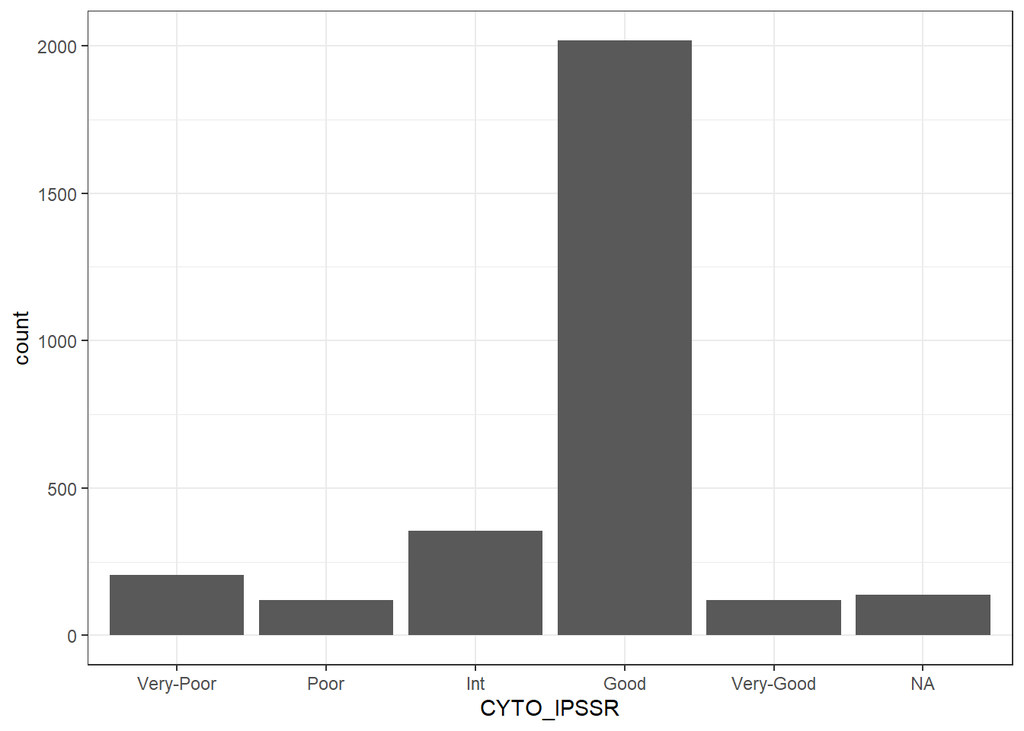

```r
plot_categorical("CYTO_IPSSR")
```

```r
descrip_categorical("CYTO_IPSSR")
```

```
## # A tibble: 6 × 3
##   CYTO_IPSSR     n  perc
##   <fct>      <int> <dbl>
## 1 Very-Poor    206   7
## 2 Poor         121   4.1
## 3 Int          356  12
## 4 Good        2018  68.2
## 5 Very-Good    119   4
## 6 <NA>         137   4.6
```

Most of the individuals presented good or very good cytogenetic results.

### Complex

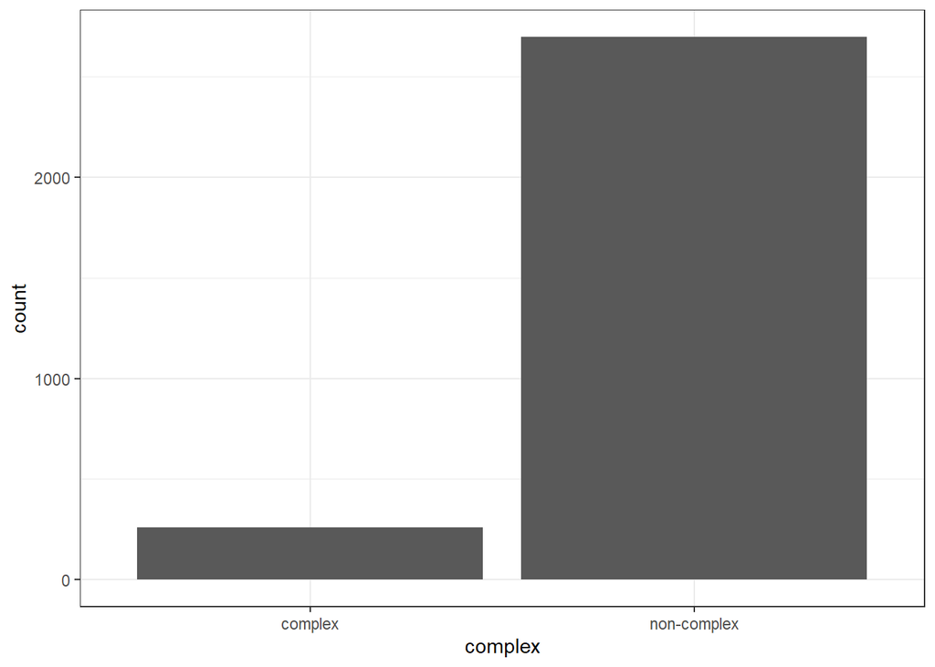

```r
plot_categorical("complex")
```

```r
descrip_categorical("complex")
```

```
## # A tibble: 2 × 3
##   complex         n  perc
##   <chr>       <int> <dbl>
## 1 complex       261   8.8
## 2 non-complex  2696  91.2
```

Some individuals present complex karyotypes.

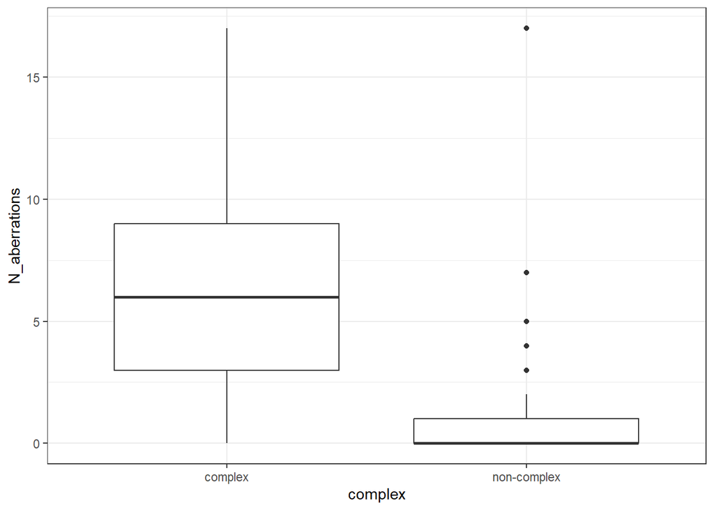

```r
ggplot(clinical_all, aes(x = complex, y = N_aberrations)) +
  geom_boxplot() +
  theme_bw()
```

Complex karyotypes had a much higher number of aberrations.

### Karyotype events

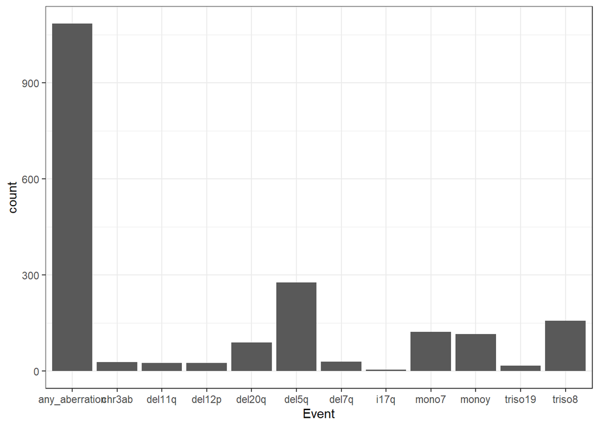

```r
clin_cyto <- clinical_all %>%
  select(kar_events) %>%
  gather(Event, Value) %>%
  filter(Value != 0)

ggplot(clin_cyto, aes(x = Event)) +
    geom_bar() +
  theme_bw()
```

```r
clin_cyto %>%
  count(Event) %>%
    mutate(perc = round(n/nrow(clinical_all)*100, 1)) %>%
  arrange(desc(n))
```

```
## # A tibble: 12 × 3
##    Event              n  perc
##    <chr>          <int> <dbl>
##  1 any_aberration  1084  36.7
##  2 del5q            276   9.3
##  3 triso8           158   5.3
##  4 mono7            122   4.1
##  5 monoy            116   3.9
##  6 del20q            90   3
##  7 del7q             29   1
##  8 chr3ab            28   0.9
##  9 del12p            26   0.9
## 10 del11q            25   0.8
## 11 triso19           17   0.6
## 12 i17q               4   0.1
```

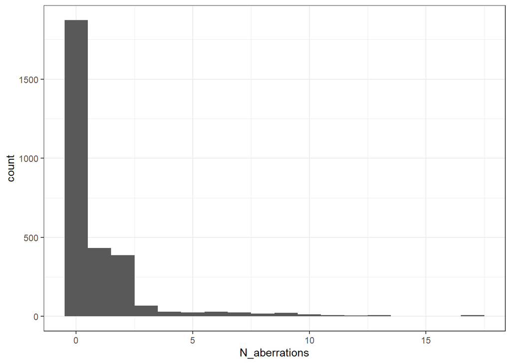

```r
plot_continuous("N_aberrations", 1)
```

```r
descrip_continuous("N_aberrations", 10)
```

```
## # A tibble: 10 × 3
##    intervals       n  perc
##    <fct>       <int> <dbl>
##  1 [0,1.7]      2305  78
##  2 (1.7,3.4]     456  15.4
##  3 (3.4,5.1]      55   1.9
##  4 (5.1,6.8]      29   1
##  5 (6.8,8.5]      41   1.4
##  6 (8.5,10.2]     36   1.2
##  7 (10.2,11.9]     8   0.3
##  8 (11.9,13.6]    13   0.4
##  9 (13.6,15.3]     3   0.1
## 10 (15.3,17]      11   0.4
```

Most individuals did not have any karyotipic event. Patients with events had 1 or 2.

## MDS subtypes

```r
mds_types <- c("MDS_TYPE", "WHO_2016")
```

### MDS type

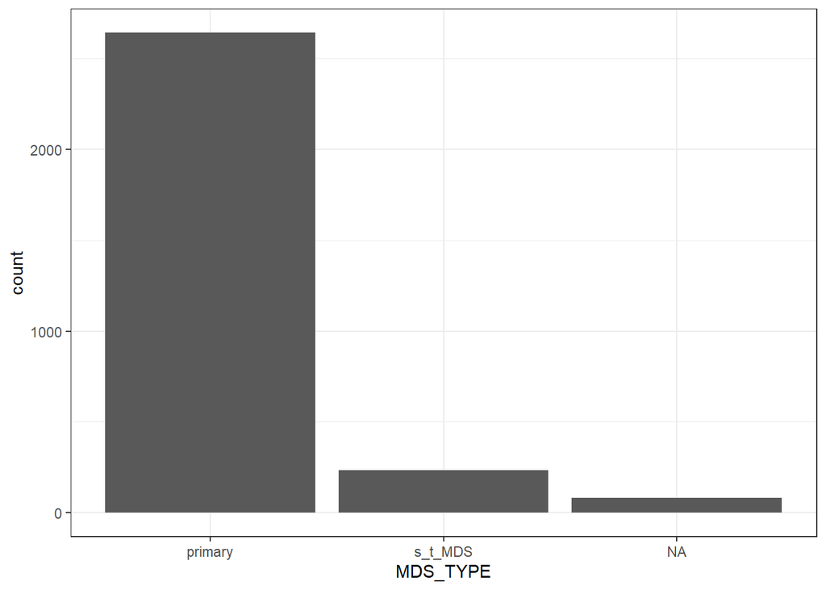

```r
plot_categorical("MDS_TYPE")
```

```r
descrip_categorical("MDS_TYPE")
```

```
## # A tibble: 3 × 3
##   MDS_TYPE     n  perc
##   <chr>    <int> <dbl>
## 1 primary   2641  89.3
## 2 s_t_MDS    234   7.9
## 3 <NA>        82   2.8
```

Most patients are primary MDS. However, a subset where secondary or therapy related MDS.

### WHO subtypes

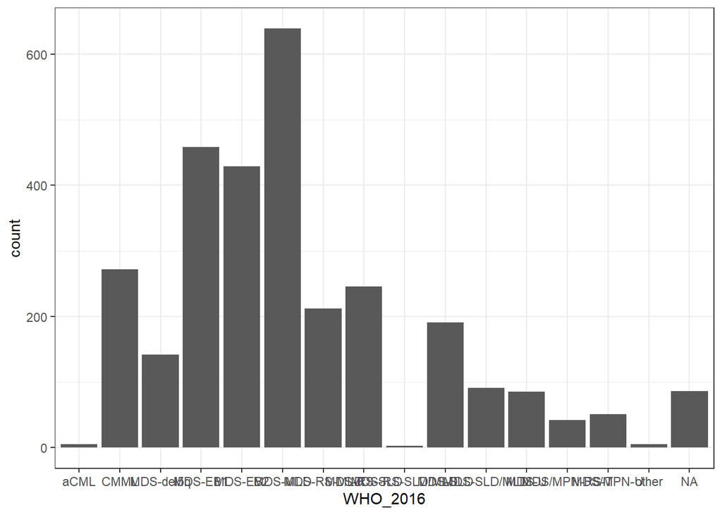

```r
plot_categorical("WHO_2016")
```

```r
descrip_categorical("WHO_2016")  %>%
  arrange(desc(n))
```

```
## # A tibble: 16 × 3
##    WHO_2016           n  perc
##    <chr>          <int> <dbl>
##  1 MDS-MLD          639  21.6
##  2 MDS-EB1          458  15.5
##  3 MDS-EB2          429  14.5
##  4 CMML             272   9.2
##  5 MDS-RS-SLD       246   8.3
##  6 MDS-RS-MLD       212   7.2
##  7 MDS-SLD          191   6.5
##  8 MDS-del5q        142   4.8
##  9 MDS-SLD/MLD       91   3.1
## 10 <NA>              86   2.9
## 11 MDS-U             85   2.9
## 12 MDS/MPN-U         51   1.7
## 13 MDS/MPN-RS-T      42   1.4
## 14 aCML               5   0.2
## 15 other              5   0.2
## 16 MDS-RS-SLD/MLD     3   0.1
```

Most frequent categories are MDS-MLD or MDS with excess of blasts (EB1 and/or EB2)

## IPSS scores

```r
scores <- c("IPSSR", "IPSSR_SCORE", "IPSSRA", "IPSSRA_SCORE", "IPSSM", "IPSSM_SCORE")
```

### IPSSR

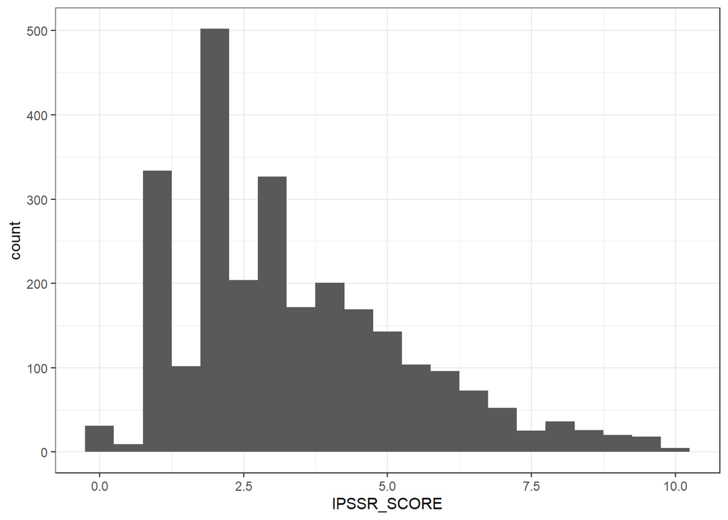

```r
plot_continuous("IPSSR_SCORE", 0.5)
```

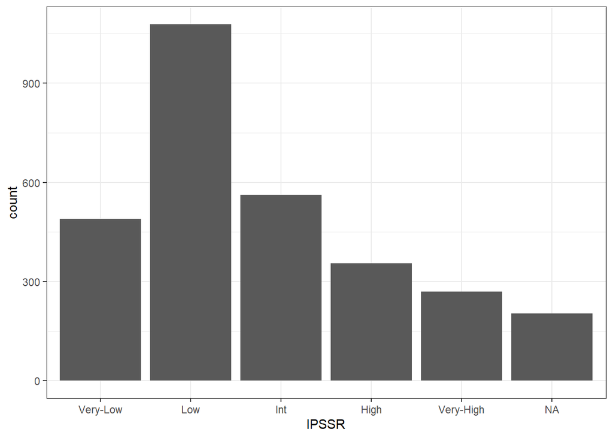

```r
plot_categorical("IPSSR")
```

```r
descrip_categorical("IPSSR")
```

```
## # A tibble: 6 × 3
##   IPSSR         n  perc
##   <fct>     <int> <dbl>
## 1 Very-Low    489  16.5
## 2 Low        1078  36.5
## 3 Int         562  19
## 4 High        355  12
## 5 Very-High   269   9.1
## 6 <NA>        204   6.9
```

Individuals are more likely to have low IPSSR scores. For low scores, there is a tendency to overestimate entire scores (i.e. 1, 2,…)

### IPSSRA

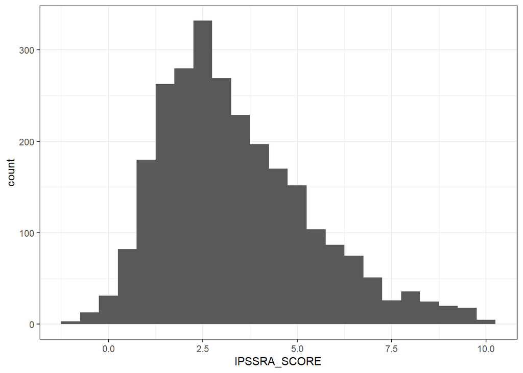

```r
plot_continuous("IPSSRA_SCORE", 0.5)
```

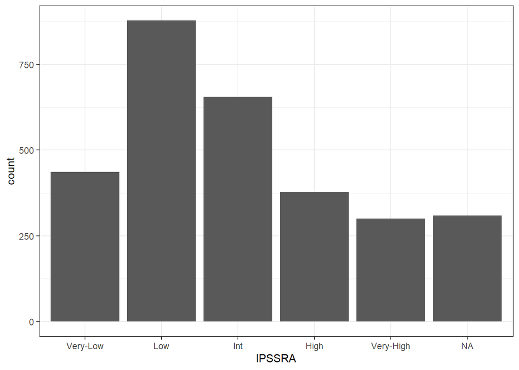

```r
plot_categorical("IPSSRA")
```

```r
descrip_categorical("IPSSRA")
```

```
## # A tibble: 6 × 3
##   IPSSRA        n  perc
##   <fct>     <int> <dbl>
## 1 Very-Low    436  14.7
## 2 Low         878  29.7
## 3 Int         656  22.2
## 4 High        378  12.8
## 5 Very-High   300  10.1
## 6 <NA>        309  10.4
```

The IPSSRA scores show a more normal distribution. Nonetheless, it still predominates the individuals with low scores.

### IPSSM

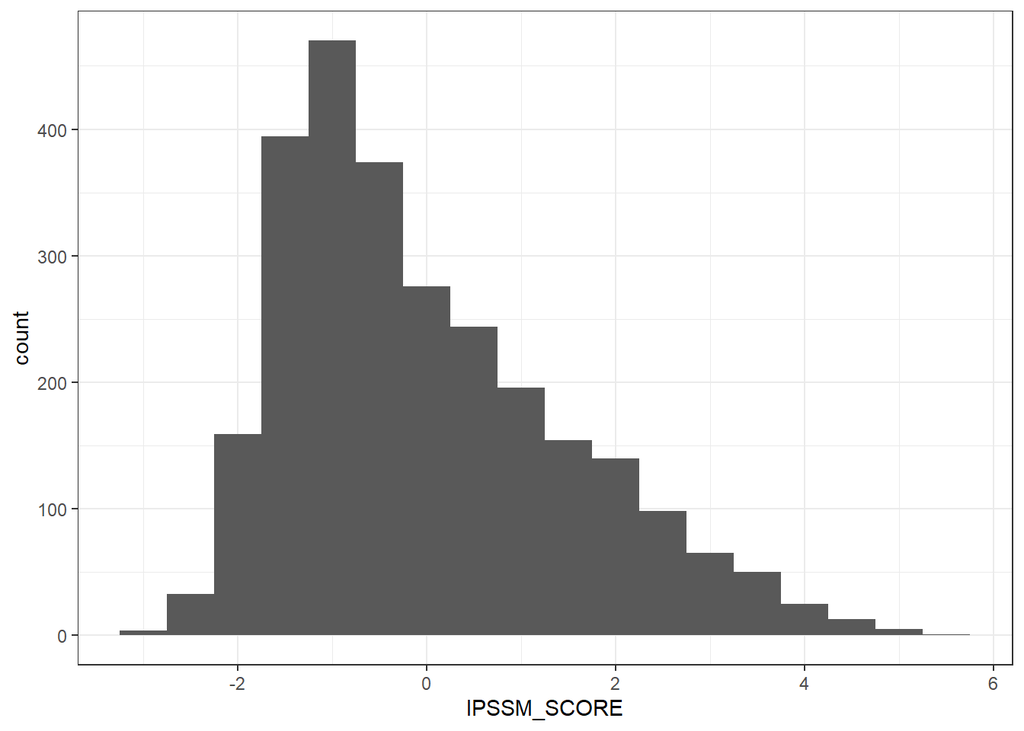

```r
plot_continuous("IPSSM_SCORE", 0.5)
```

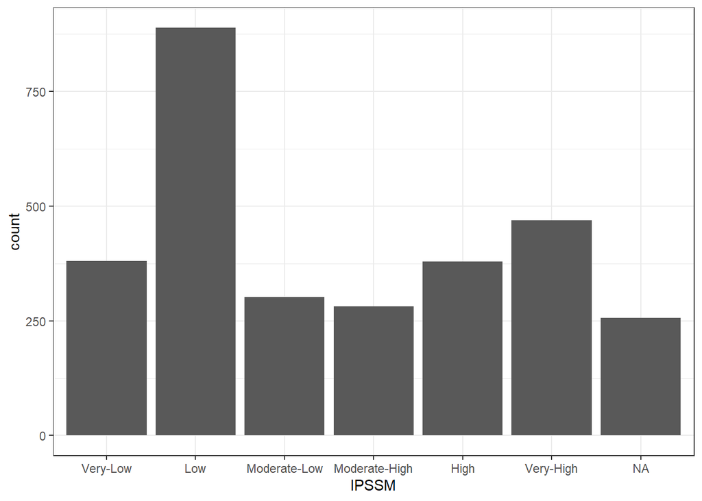

```r
plot_categorical("IPSSM")
```

```r
descrip_categorical("IPSSM")
```

```
## # A tibble: 7 × 3
##   IPSSM             n  perc
##   <fct>         <int> <dbl>
## 1 Very-Low        381  12.9
## 2 Low             889  30.1
## 3 Moderate-Low    302  10.2
## 4 Moderate-High   281   9.5
## 5 High            379  12.8
## 6 Very-High       469  15.9
## 7 <NA>            256   8.7
```

The IPSSM scores show also negative values, reflecting individuals with lower risk than expected. Nonetheless, it still biased to low risk individuals.

## Outcomes

```r
outcomes <- c("OS_YEARS", "OS_STATUS", "AMLt_YEARS", "AMLt_STATUS", "LFS_YEARS", "LFS_STATUS" )
```

### Overall Survival

```r
os_surv <- survfit(Surv(OS_YEARS,OS_STATUS) ~ 1, clinical_all)
print(os_surv)
```

```
## Call: survfit(formula = Surv(OS_YEARS, OS_STATUS) ~ 1, data = clinical_all)
##
##    146 observations deleted due to missingness
##         n events median 0.95LCL 0.95UCL
## [1,] 2811   1354   3.55    3.29    3.88
```

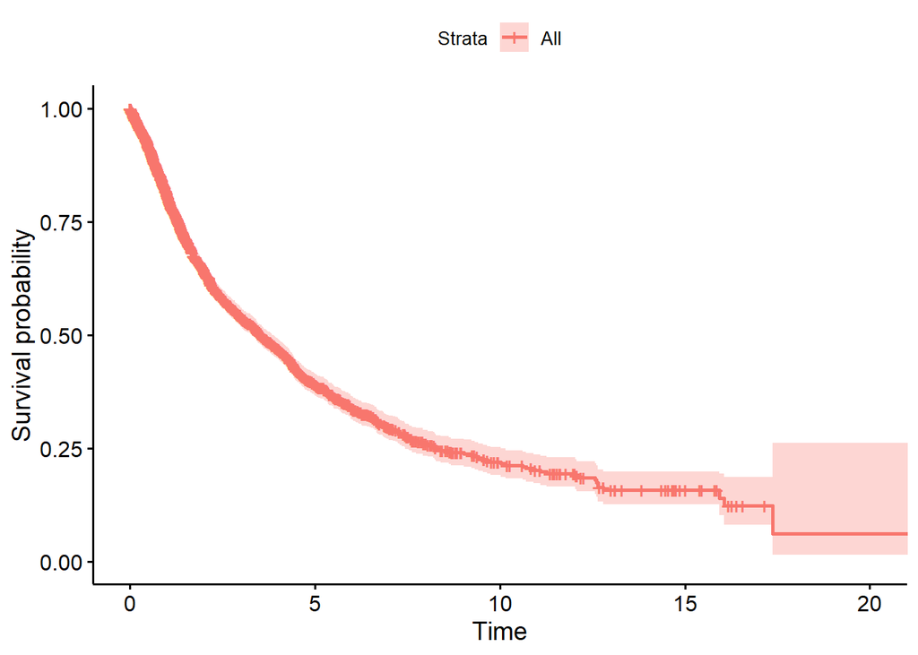

```r
ggsurvplot(os_surv, data = clinical_all)
```

### Acute Myeloid Leukemia transformation;

```r
aml_surv <- survfit(Surv(AMLt_YEARS,AMLt_STATUS) ~ 1, clinical_all)
print(aml_surv)
```

```
## Call: survfit(formula = Surv(AMLt_YEARS, AMLt_STATUS) ~ 1, data = clinical_all)
##
##    324 observations deleted due to missingness
##         n events median 0.95LCL 0.95UCL
## [1,] 2633    415     NA      NA      NA
```

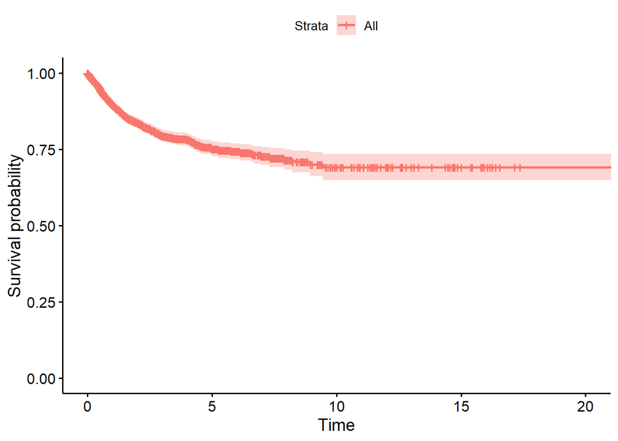

```r
ggsurvplot(aml_surv, data = clinical_all)
```

A small proportion of patients developed Acute Myeloid Leukemia transformation. Transformation happened relative early.

### Leukemia-Free Survival

```r
lfs_surv <- survfit(Surv(LFS_YEARS,LFS_STATUS) ~ 1, clinical_all)
print(lfs_surv)
```

```
## Call: survfit(formula = Surv(LFS_YEARS, LFS_STATUS) ~ 1, data = clinical_all)
##
##    341 observations deleted due to missingness
##         n events median 0.95LCL 0.95UCL
## [1,] 2616   1352   2.91    2.67    3.27
```

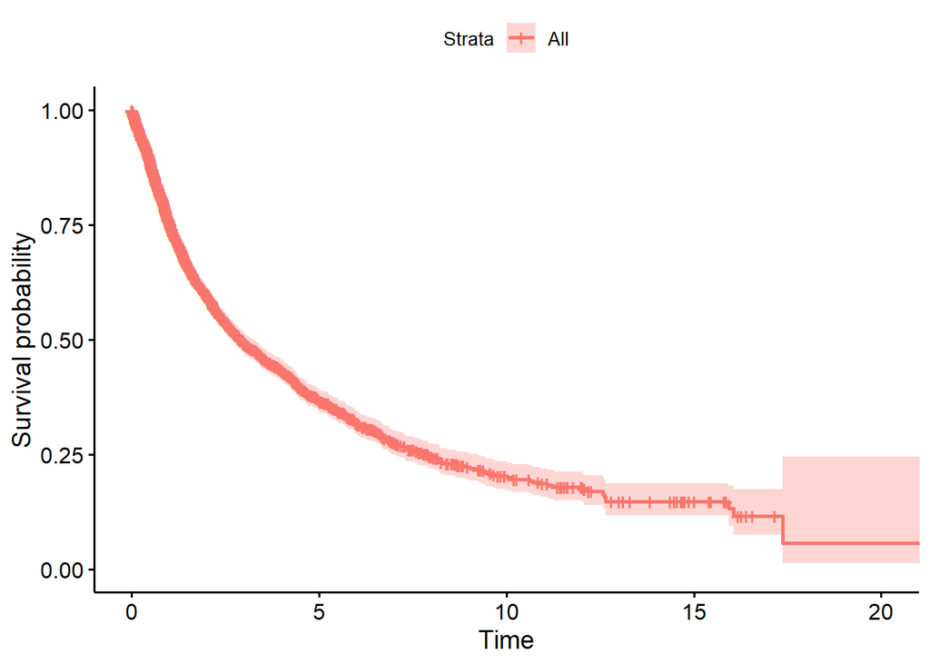

```r
ggsurvplot(lfs_surv, data = clinical_all)
```

A similar proportion of patients that died developed leukemia. The decrease is sharper and peaks around 3 years after starting the follow-up.

## Treatments

```r
treatments <- c("hma", "lenalidomid", "chemotherapy", "transplant")
```

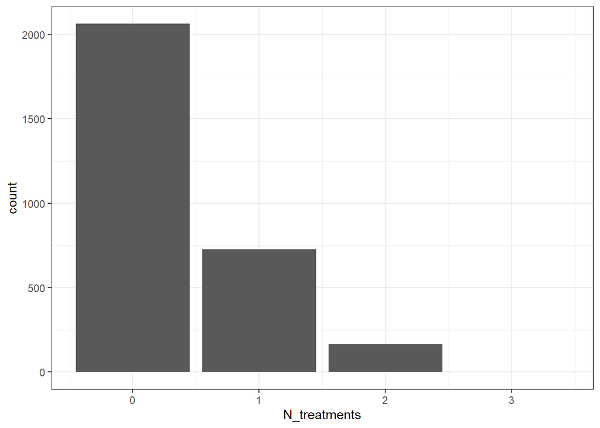

```r
clinical_all <- clinical_all %>%
  mutate(N_treatments = hma + lenalidomid + chemotherapy + transplant)


plot_categorical("N_treatments")
```

```r
descrip_categorical("N_treatments")
```

```
## # A tibble: 4 × 3
##   N_treatments     n  perc
##          <dbl> <int> <dbl>
## 1            0  2063  69.8
## 2            1   728  24.6
## 3            2   164   5.5
## 4            3     2   0.1
```

Most patients did not have any treatment. Of the patients treated, most have just one treatment.

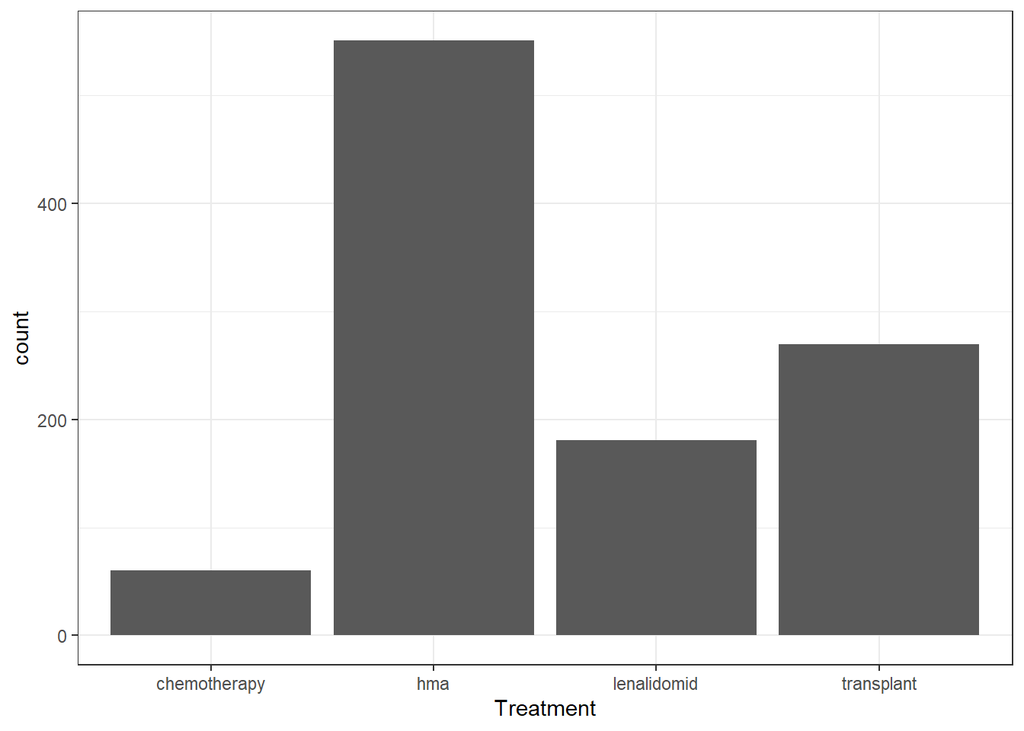

```r
clin_sum <- clinical_all %>%
  select(hma, lenalidomid, chemotherapy, transplant) %>%
  gather(Treatment, Value) %>%
  filter(Value != 0)

ggplot(clin_sum, aes(x = Treatment)) +
    geom_bar() +
  theme_bw()
```

```r
clin_sum %>%
  count(Treatment)
```

```
## # A tibble: 4 × 2
##   Treatment        n
##   <chr>        <int>
## 1 chemotherapy    60
## 2 hma            551
## 3 lenalidomid    181
## 4 transplant     270
```

The most frequent treatment was hypomethylation agents (hma).